# Using Copilot (Basic) to create a map

### 3. Move Victoria inset

Currently it is too low and too far right.

Replace:

```r
draw_plot(
  vic_inset,
  x = 0.73,
  y = 0.50,
  width = 0.24,
  height = 0.24
)
```

with:

```r
draw_plot(
  vic_inset,
  x = 0.68,
  y = 0.62,
  width = 0.22,
  height = 0.22
)
```

This places it:

- aligned with the top of the map frame
- slightly right of centre
- clear of the legend

### 4. White background for Victoria inset

Change:

```r
vic_inset <- ggplot() +
```

to:

```r
vic_inset <- ggplot() +

  theme_void() +

  theme(
    panel.background = element_rect(
      fill = "white",
      colour = NA
    ),
    plot.background = element_rect(
      fill = "white",
      colour = NA
    ),
    panel.border = element_rect(
      fill = NA,
      colour = "black",
      linewidth = 0.8
    )
  )
```

### 5. Make inset border more prominent

Currently:

```r
linewidth = 0.8
```

I’d use:

```r
linewidth = 1.2
```

for publication maps.

### 6. Zoom box should match inset

The red box on the main map currently occupies a larger area than the zoom inset actually shows.

Replace:

```r
zoom_bbox <- st_bbox(
  st_buffer(
    st_union(zoom_dat),
    500
  )
)
```

with:

```r
zoom_buffer <- 250

zoom_bbox <- st_bbox(
  st_buffer(
    st_union(zoom_dat),
    zoom_buffer
  )
)
```

This will:

- tighten the zoom area
- make the inset more focused
- produce a smaller red highlighting box

### 7. Arrow should terminate at inset edge

Your arrow currently lands in empty space.

Instead:

```r
annotate(
  "segment",
  x = zx,
  y = zy,
  xend = zx - 6000,
  yend = zy - 4000,
  ...
)
```

Use something closer to:

```r
annotate(
  "segment",
  x = zx,
  y = zy,
  xend = zx - 3500,
  yend = zy - 2500,
  colour = "black",
  linewidth = 0.8,
  arrow = arrow(length = unit(0.25, "cm"))
)
```

after reducing the inset size.

### 8. Export settings

Since the RStudio zoomed version looks good, I’d actually reduce physical output size:

Current:

```r
width = 12
height = 8
dpi = 600
```

Change to:

```r
width = 10
height = 7
dpi = 600
```

This keeps publication quality but effectively makes all labels ~20% larger relative to the figure.

### 9. Recommended final layout

For final_map:

```r
final_map <-
  ggdraw(main_map) +

  draw_plot(
    zoom_map,
    x = 0.09,
    y = 0.12,
    width = 0.15,
    height = 0.15
  ) +

  draw_plot(
    vic_inset,
    x = 0.68,
    y = 0.62,
    width = 0.22,
    height = 0.22
  )
```

I think this will give a result much closer to the original QGIS figure:

- zoom inset smaller
- zoom inset shifted right
- more prominent labels
- Victoria inset aligned with map top
- white inset background
- stronger border
- less dominant inset footprint.

There are still a few more issues around text and inset locations, but if we use the zoomed version we get colers to somehting that is usable, and with a bit of tinkering with location values, we could get to an acceptable map.

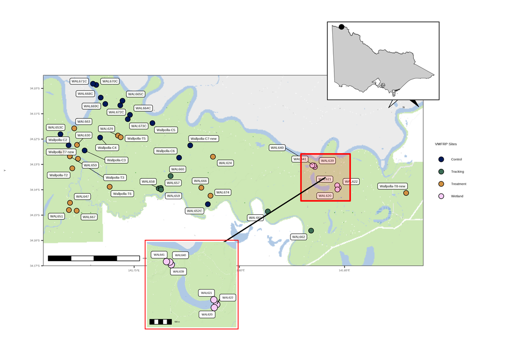

The final map that was saved through the updated process

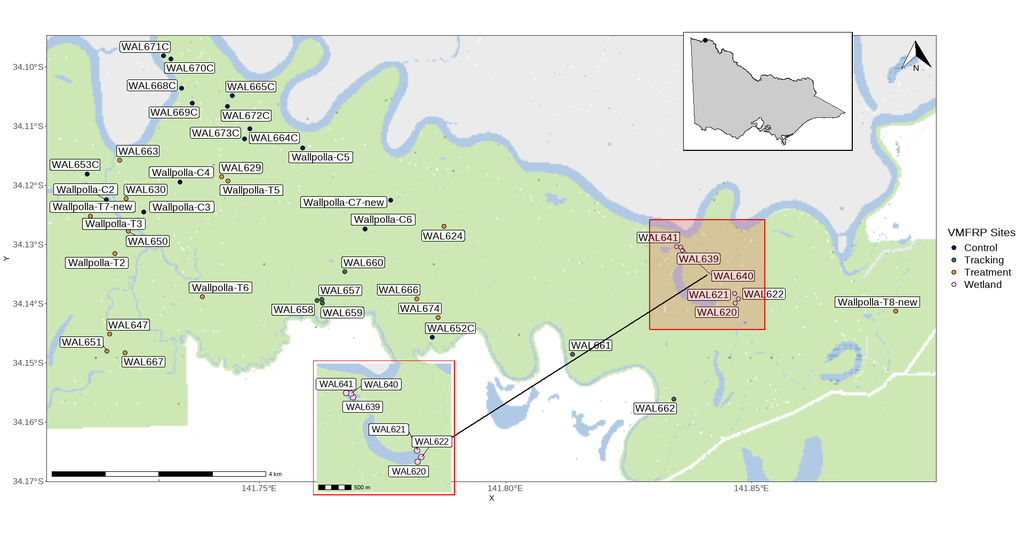

What was produced in R

### download_spatial_data.R

```r
# ============================================================
# VMFRP Wallpolla Map Setup
#
# Downloads and caches:
#   1. Vicmap Basemap (Cartographic, VicGrid2020)
#   2. Victoria administrative boundary
#
# Outputs:
#   data/spatial/vicmap_topographic/vicmap_wallpolla.tif
#   data/spatial/victoria_boundary.gpkg
#
# ============================================================

library(sf)
library(terra)
library(dplyr)
library(geodata)

# ------------------------------------------------------------
# Settings
# ------------------------------------------------------------

buffer_distance <- 5000  # metres

dir.create(
  "data/spatial/vicmap_topographic",
  recursive = TRUE,
  showWarnings = FALSE
)

# ------------------------------------------------------------
# Load site data
# ------------------------------------------------------------

message("Reading site data...")

sites <- st_read(
  "data/spatial/vmfrp_wallpolla_veg.gpkg",
  quiet = TRUE
)

sites <- st_transform(sites, 7899)

# ------------------------------------------------------------
# Calculate study area extent
# ------------------------------------------------------------

message("Calculating extent...")

study_extent <- st_buffer(
  st_union(sites),
  dist = buffer_distance
)

bb <- st_bbox(study_extent)

e <- ext(
  bb["xmin"],
  bb["xmax"],
  bb["ymin"],
  bb["ymax"]
)

# ------------------------------------------------------------
# Download Victoria boundary
# ------------------------------------------------------------

boundary_file <- "data/spatial/victoria_boundary.gpkg"

if (!file.exists(boundary_file)) {

  message("Downloading Australian administrative boundaries...")

  aus_states <- geodata::gadm(
    country = "AUS",
    level = 1,
    path = tempdir()
  )

  aus_states_sf <- sf::st_as_sf(aus_states)

  vic <- aus_states_sf |>
    dplyr::filter(NAME_1 == "Victoria") |>
    sf::st_transform(7899)

  sf::st_write(
    vic,
    boundary_file,
    delete_dsn = TRUE,
    quiet = TRUE
  )

  message("Victoria boundary saved.")

} else {

  message("Victoria boundary already present.")

}

# ------------------------------------------------------------
# Connect to Vicmap WMTS
# ------------------------------------------------------------

message("Connecting to Vicmap WMTS...")

vicmap <- rast(
  paste0(
    "WMTS:",
    "https://base.maps.vic.gov.au/service",
    "?service=WMTS",
    "&request=GetCapabilities",
    ",layer=CARTO_VG2020"
  )
)

# ------------------------------------------------------------
# Crop to study area
# ------------------------------------------------------------

message("Downloading required map tiles...")

basemap <- crop(
  vicmap,
  e,
  snap = "out"
)

target_res <- 5

basemap_small <- terra::resample(
  basemap,
  terra::rast(
    ext = terra::ext(basemap),
    resolution = target_res,
    crs = crs(basemap)
  ),
  method = "near"
)

# ------------------------------------------------------------
# Save local cache
# ------------------------------------------------------------

outfile <- file.path(
  "data/spatial/vicmap_topographic",
  "vicmap_wallpolla.tif"
)

message("Writing GeoTIFF cache...")

writeRaster(
  basemap_small,
  outfile,
  overwrite = TRUE,
  gdal = c(
    "COMPRESS=DEFLATE",
    "PREDICTOR=2"
  )
)

message("Completed.")

message(paste("Cached basemap:", outfile))
```

### create_vmfrp_map.R

```r
#### Packages ####
library(sf)
library(terra)

library(dplyr)

library(ggplot2)
library(ggrepel)

library(ggspatial)

library(cowplot)
library(patchwork)

library(scico)

library(showtext)
library(grid)

library(ggspatial)

#### Configuration ####

dpi <- 600

fig_width <- 10
fig_height <- 7

buffer_distance <- 5000

zoom_sites <- c(
  "WAL620",
  "WAL621",
  "WAL622",
  "WAL639",
  "WAL640",
  "WAL641"
)

#### Fonts ####

showtext_auto()

# font_add(
#   family = "VIC Regular",
#   regular = "VIC-Regular.ttf"
# )
#
# font_add(
#   family = "VIC Bold",
#   regular = "VIC-Bold.ttf"
# )

#### Load Data ####

sites <- st_read(
  "data/spatial/vmfrp_wallpolla_veg.gpkg",
  quiet = TRUE
)

sites <- st_transform(sites, 7899)

vic_boundary <- st_read(
  "data/spatial/victoria_boundary.gpkg",
  quiet = TRUE
)

# We already had basemap
basemap <- rast(
  "data/spatial/vicmap_topographic/vicmap_wallpolla.tif"
)

library(png)
library(grid)

spatraster_to_grob <- function(r) {

  tf <- tempfile(fileext = ".png")

  png(
    filename = tf,
    width = 7000,
    height = 5000,
    bg = "transparent"
  )

  terra::plotRGB(
    r,
    r = 1,
    g = 2,
    b = 3,
    mar = c(0, 0, 0, 0),
    axes = FALSE,
    asp = NA
  )

  dev.off()

  img <- png::readPNG(tf)

  rasterGrob(
    img,
    interpolate = TRUE
  )
}

basemap_grob <- spatraster_to_grob(basemap)

sites_lab <- sites |>
  cbind(
    st_coordinates(sites)
  )

#### Colours ####
bat <- scico(
  n = 4,
  palette = "batlow"
)

site_cols <- c(
  Control   = bat[1],
  Tracking  = bat[2],
  Treatment = bat[3],
  Wetland   = bat[4],
  Unknown   = "grey70"
)

#### Main Extent ####

bm_ext <- terra::ext(basemap)

xmin <- bm_ext$xmin
xmax <- bm_ext$xmax
ymin <- bm_ext$ymin
ymax <- bm_ext$ymax

#### Main Map ####
main_map <- ggplot() +

  annotation_custom(
    basemap_grob,
    xmin = xmin,
    xmax = xmax,
    ymin = ymin,
    ymax = ymax
  ) +

  geom_sf(
    data = sites,
    aes(fill = regime_typ),
    shape = 21,
    colour = "black",
    stroke = 0.5,
    size = 3
  ) +

  geom_label_repel(
    data = sites_lab,
    aes(
      x = X,
      y = Y,
      label = site_code
    ),
    max.overlaps = Inf,
    fill = scales::alpha("white", 0.85),
    label.size = 0.25,
    box.padding = 0.3,
    point.padding = 0.2,
    segment.size = 0.25,
    size = 5,
    label.padding = unit(0.2, "lines")
  ) +

  coord_sf(
    xlim = c(xmin, xmax),
    ylim = c(ymin, ymax),
    expand = FALSE
  ) +

  scale_fill_manual(
    values = site_cols,
    name = "VMFRP Sites"
  ) +

  annotation_scale(
    location = "bl"
  ) +

  annotation_north_arrow(
    location = "tr",
    which_north = "true"
  ) +

  theme_bw() +

  theme(
    plot.title = element_text(size = 24),
    legend.title = element_text(size = 16),
    legend.text = element_text(size = 14),
    axis.text = element_text(size = 12)
  )


#### Victoria Inset ####
##### Study centroid #####
study_centroid <- st_centroid(
  st_union(
    st_geometry(sites)
  )
)

##### Inset plot #####
vic_inset <- ggplot() +

  geom_sf(
    data = vic_boundary,
    fill = "grey80",
    colour = "grey20"
  ) +

  geom_sf(
    data = study_centroid,
    size = 3,
    colour = "black"
  ) +

  theme_void() +

  theme(
    panel.background = element_rect(
      fill = "white",
      colour = NA
    ),
    plot.background = element_rect(
      fill = "white",
      colour = NA
    ),
    panel.border = element_rect(
      fill = NA,
      colour = "black",
      linewidth = 0.8
    )
  )

#### Zoom Inset ####

zoom_dat <- sites |>
  filter(site_code %in% zoom_sites)

zoom_bbox <- st_bbox(
  st_buffer(
    st_union(zoom_dat),
    500
  )
)

zoom_raster <- crop(
  basemap,
  ext(
    zoom_bbox["xmin"],
    zoom_bbox["xmax"],
    zoom_bbox["ymin"],
    zoom_bbox["ymax"]
  )
)

zoom_png <- tempfile(fileext = ".png")

png(
  zoom_png,
  width = 4000,
  height = 4000,
  bg = "transparent"
)

plotRGB(
  zoom_raster,
  r = 1,
  g = 2,
  b = 3,
  axes = FALSE,
  box = FALSE,
  mar = c(0,0,0,0)
)

dev.off()

zoom_img <- png::readPNG(zoom_png)

zoom_grob <- rasterGrob(
  zoom_img,
  interpolate = TRUE
)

zoom_lab <- bind_cols(
  zoom_dat,
  as.data.frame(st_coordinates(zoom_dat))
)

zoom_map <- ggplot() +

  annotation_custom(
    zoom_grob,
    xmin = zoom_bbox["xmin"],
    xmax = zoom_bbox["xmax"],
    ymin = zoom_bbox["ymin"],
    ymax = zoom_bbox["ymax"]
  ) +

  geom_sf(
    data = zoom_dat,
    aes(fill = regime_typ),
    shape = 21,
    colour = "black",
    size = 4,
    stroke = 0.5
  ) +

  geom_label_repel(
    data = zoom_lab,
    aes(
      x = X,
      y = Y,
      label = site_code
    ),
    max.overlaps = Inf,
    size = 4.5
  ) +

  scale_fill_manual(
    values = site_cols
  ) +

  coord_sf(
    xlim = c(zoom_bbox["xmin"], zoom_bbox["xmax"]),
    ylim = c(zoom_bbox["ymin"], zoom_bbox["ymax"]),
    expand = FALSE
  ) +

  annotation_scale(
    location = "bl"
  ) +

  theme_void() +

  theme(
    panel.border = element_rect(
      colour = "red",
      fill = NA,
      linewidth = 1
    ),
    legend.position = "none"
  )

#### Assemble Layout ####

zoom_poly <- st_as_sfc(
  zoom_bbox
)

zoom_centre <- st_centroid(
  st_as_sfc(zoom_bbox)
)

zc <- st_coordinates(zoom_centre)

final_map <- ggdraw(main_map +
                      geom_sf(
                        data = zoom_poly,
                        fill = scales::alpha("red", 0.15),
                        colour = "red",
                        linewidth = 1) +
                      annotate(
                        "segment",
                        x = zc[1],
                        y = zc[2],
                        xend = zc[1] - 5500,
                        yend = zc[2] - 3500,
                        colour = "black",
                        linewidth = 0.8,
                        arrow = arrow(length = unit(0.2, "cm"))
                      )) +

  draw_plot(
    vic_inset,
    x = 0.64,
    y = 0.72,
    width = 0.22,
    height = 0.22
  ) +

  draw_plot(
    zoom_map,
    x = 0.25,
    y = 0.08,
    width = 0.25,
    height = 0.25
  )

#### Export ####

ggsave(
  filename = "figures/rmap.png",
  plot = final_map,
  width = fig_width,
  height = fig_height,
  units = "in",
  dpi = 300,
  bg = "white"
)
```